# Overview of the Rock Cycle

Dr Ahmad Redaa

2024-08-26

# Key Questions

- What is Petrology?
- Why Should We Study Rocks?
- What is the Difference Between Rocks and Minerals?
- How Abundant Are Different Rock Types on Earth?
- How Do Rocks Change from One Form to Another?
- Are There Inherited Criteria for Tracking Rock Changes?

# The Rock Cycle and Involved Processes

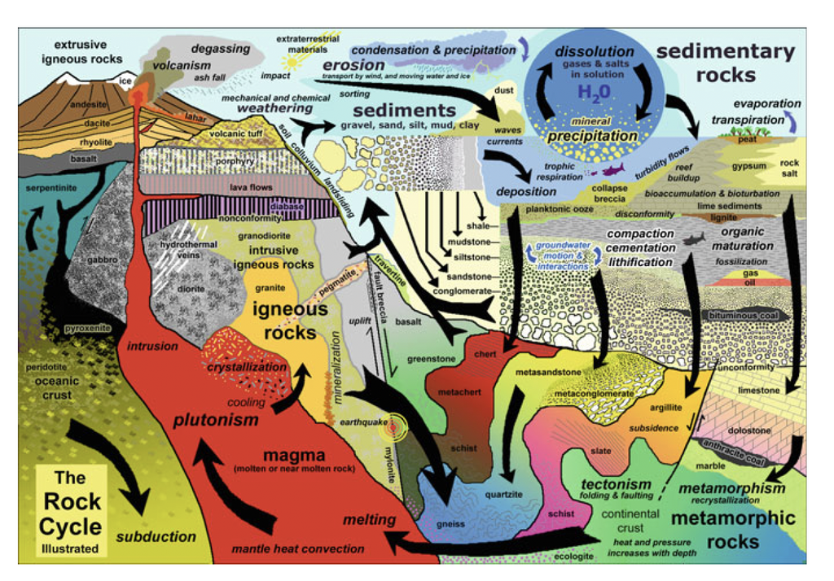

The Rock Cycle, Source: [Jain, S. (2014)](https://doi.org/10.1007/978-81-322-1539-4)

# Summary

- **Rock Types Produced Through the Cycle:**
  - **Igneous Rocks:** Formed from the solidification of molten magma or lava (e.g., basalt, granite).
  - **Sedimentary Rocks:** Formed from the accumulation and compaction of sediments (e.g., sandstone, limestone).
  - **Metamorphic Rocks:** Formed from the transformation of existing rocks due to heat, pressure, or chemically active fluids (e.g., marble, schist).
- **Processes That Change Rocks From Form to Form:**
  - **Cooling and Solidification:** Magma cools and solidifies to form igneous rocks.
  - **Weathering and Erosion:** Igneous and metamorphic rocks break down into sediments.
  - **Compaction and Cementation:** Sediments compact and cement together to form sedimentary rocks.
  - **Metamorphism:** Sedimentary and igneous rocks undergo heat and pressure to become metamorphic rocks.
  - **Melting:** Metamorphic and sedimentary rocks melt into magma, starting the cycle again.